# FSA_note

1. 名词解释
2. 简答题
3. 分析题(2道大题)
   - 课件上的案例不会出现，只会考考点

### 第一章 导言

- 企业财务报表通过对企业某一特定日期的*财务状况*（我们可以将企业的财务状况简单地理解为企业从货币角度表现出来的基本存在状态）以及一定时期的*经营成果*（ 这里的经营成果既包括利润也包括现金流量等） 的具体列报，全面揭示企业各项经济活动的过程及其经济后果
- 实质重于形式
  - 股权的表决权可能比股权本身所有权更重要
- 反常现象：高资产 & 高负债
  - 有了高资产之后，应当冲抵负债
  - 如果出现这种情况，很可能现金总量是虚假的
- 过高的在建工程很可能隐藏了泡沫资产（可疑科目）
  - 相关科目(有钩稽关系的科目)：固定资产（转固，转入固定资产）$\uparrow$；银行存款$\downarrow$；应付账款$\uparrow$；预付账款$\downarrow$
- 财报的基本内容(四表一注)
  - 资产负债表
    - 资产按流动性排列
      - 流动资产
        - 轻资产企业流动性资产多，风险相对较少，重资产企业反之
      - 长期投资
        - 对外股权投资可以看出多元化程度
      - 固定资产
      - 其他资产
    - 负债按到期日排序
      - 流动负债
        - 预收账款、应付账款、合同负债、应付工程款等是一种无息负债
        - 扣除无息负债之后，才能计算实际负债率
      - 长期负债
      - 其他负债
        - 表外融资：通过项目进行股权融资，约定期限与股权回购条款(明股实债)
    - 所有者权益
      - 股本
        - 只有控股公司的财务才需要进行合并报表
      - 未分配利润
      - 公积金
    - $资产 = 负债 + 所有者权益$
  - 利润表

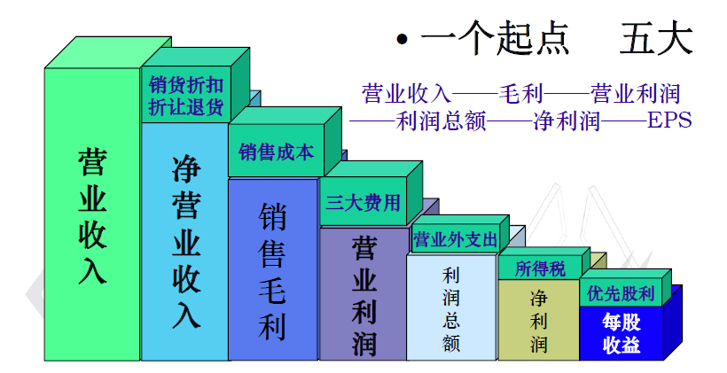

### 第二章 财务分析的哈佛框架

1. 会计分析
2. 财务分析
3. 前景分析
4. 战略分析

#### 战略分析

1. 行业分析（五大力量理论）
   1. 现存对手之间的竞争
   2. 新进入对手的威胁
   3. 替代产品的威胁
   4. 与消费者的议价能力
   5. 与供应商的议价能力
      - 通过行业分析，可以得知企业是否进行了财务造假，也可以猜测企业的核心竞争力
1. 竞争战略分析
   1. 低成本竞争: 以最低的成本提供同质化产品或服务的战略
      - 注重成本管理
      - e.g 戴尔的低成本战略
        1. 直销
        2. 订单制造
        3. 战略联盟
        4. 外包维修
        5. 选择性研发
        6. 弹性雇佣
   2. 差异化竞争：以低于消费者支付意愿的价格提供独特产品或服务的战略
      - 注重产品革新
      - e.g 苹果的转型
      - 高科技企业重要指标：$\frac{R\&D投入}{销售收入}$
        - 微软为$10\%$~$15\%$
        - 苹果仅为$3\%$左右,是因为iTunes和App Store分摊了大量研发成本
   3. 识别竞争战略
      1. 低成本战略
         1. $\arg_{\max}总资产周转率=\frac{营业收入}{总资产}$
         2. $\arg_{\max}固定资产周转率=\frac{营业收入}{固定资产}$
         3. $\arg_{\min}\frac{销售费用}{营业收入}$,$\arg_{\min}\frac{管理费用}{营业收入}$
         4. $\arg_{\max}员工效率=\frac{营业收入}{员工薪酬}$
      2. 差异化竞争
         1. $\arg_{\max}毛利率=\frac{（营业收入—营业成本）}{营业收入}$
         2. $\arg_{\max}销售费用收入率=\frac{销售费用}{营业收入}$
         3. $\arg_{\max}研发费用比例率=\frac{研发费用}{营业收入}$
1. 企业战略分析：多元化 & 专一化

#### 会计分析：资产负债表解读

##### 资产

- 资产的定义
  1. 本质是未来的经济利益
  2. 能够为企业所拥有或控制
  3. 由于过去的交易或事项而形成
  4. 必须能够以货币进行计量
- 资产的分类：流动性分类
  - 流动资产：
    - 现金
    - 交易性金融资产
    - 应收账款
    - 存货
    - 其他应收款
  - 非流动资产
    - 长期股权投资
    - 固定资产
    - 在建工程
    - 无形资产
    - 投资性房地产
    - 可供出售金融资产
    - 递延所得税资产
  - 生物性资产
    - 消耗性生物资产
      - 用来卖的农产品
      - 为出售而持有的，或在将来收获为农产品的生物资产，包括生长中的大田作物、蔬菜、用材林以及存栏待售的牲畜等
    - 生产性生物资产
      - 用于再生产的农产品,相当于生产资料
      - 为产出农产品、提供劳务或出租等目的的生物资产，包括经济林、薪炭林、产畜和役畜等
      - 生产性生物资产一般使用固定资产的折旧方式
    - 公益性生物资产
      - 用于防护、环保的农产品
      - 以防护、环境保护为主要目的的生物资产，包括防风固沙林，水土保持林和水源涵养林等
- 资产确认
  - 历史成本 & 谨慎性原则
  - 资产确认三原则
    - 拥有所有权
      - 是否有表外所有权？
      - 是否有额外的所有权协议？
      - 租赁有没有出现在表内？
    - 带来未来经济利益
      - 计价方式是否有变动？
      - 是否有毁损？毁损之后是否减值？
    - 用货币可靠计量
      - 商誉、品牌等如何计价？

##### FASB的公允价值定义

- 市场参与者(Market Participants)
  - 市场参与者独立于报告主体，即不是关联方
  - 熟悉情况、掌握信息
  - 有能力对该资产和负债进行交易
  - 自愿（而不是被迫）对该资产和负债进行交易
- 公允价值计价方法
  - 存在公开报价：Mark to Market
  - 存在可观测信息：Mark to Metrix
  - 存在不可观测信息：Mark to Model
    - 收益现值法 income approach
    - 重置成本法 cost approach

##### 现金

- 现金是流动性最强的资产
- 充足的现金是企业生存的条件
- 现金不是越多越好
- 现金是内部控制制度的最重要对象
- 现金过剩问题
  1. 家大业大
     - 资产规模巨大
  2. 聚敛钱财
     - 现金存量巨大，现金资产比例高，同时，资产负债率也较高
  3. 得天独厚
     - 巨额现金存量，高现金资产比例，低资产负债率，往往无有息负债
     - 这类企业往往可以获得独特的垄断利润
  4. 守株待兔
     - 虽也是高现金存量，但往往谈不上巨额，因为其公司规模不大；同时，其资产负债率往往极低
     - 具有良好的“壳”价值，等待被杠杆收购(随着注册制推行，壳价值越来越低)
  5. 以假乱真
     - 财务造假
- 现金的“自由度”：现金是否被限制用途？
  - e.g. 保证金存款、已质押的定期存款、上市公司中规定了具体投向的募集资金
  - 货币资金因不能随意支用而不能充当企业“真正”的支付手段
  - 很多公司表面上有大量现金，实际上给控股股东抵押了
- 货币资金虚假的信号
  1. 绝对规模庞大
  2. 与年收入或总资产相比，货币资金相对规模偏高；
  3. 货币资金在连续定期报告中变动不大
  4. 期间公司融资频繁
     - 明明很有钱，为什么还要借钱？
     - e.g. 著名的康美药业
- 资金流水造假八大手法
  - 代收代付
    - 用其他单位(而不是自己或交易方)的名义收款或付款
  - 现金结算
  - POS机刷卡
  - 伪造银行回单
  - 伪造支票存根
  - 上下游配合
    - 将虚假资金送到上下游(实际上是“人头公司”或“空壳公司”)“转流水”，从而虚构业务
  - 银行存款质押
  - 贷款变货款
    - 个人(或自己的公司)向银行贷款，然后买自己公司的货
    - 这样就将自己的贷款变成公司的货款
- 借贷资金 & 现金资产双高
  1. 特殊金融安排
     - 用本币抵押，借入外币贷款
  2. 与股东的内部交易
     - 企业有钱，但是需要借钱给股东花
  3. 虚增货币资金
     - 货币资金是假的

##### 银行存款

- 未达账项处理
  - 未达账项：在企业和银行之间，由于凭证传递上的时间差，造成一方已登记入账，而另一方尚未入账的账款
  1. 银行已记作企业的存款增加， 而企业尚未收到收款通知， 因而尚未记账的款项
     - 如托收货款、 存款利息等
     - （银收企未收）
     - 要查明款项来源和性质，必要时与合同相核对，以确认是否属于应转未转的收入
  2. 银行已记作企业存款减少， 而企业尚未收到付款通知， 因而尚未记账的款项
     - 如银行代企业支付公用事业费、 向企业收取的借款利息等
     - （银付企未付）
     - 要查明款项的去向和性质，确认是否属于应计未计的费用
  3. 企业已记作银行存款增加， 而银行尚未办妥入账手续的款项
     - 如企业存入的转账支票
     - （企收银未收）
     - 要查明款项的去向和性质，确认是否属于虚转成本
  4. 企业已记银行存款减少，而银行尚未支付的款项
     - 如企业已开出的转账支票，对方尚未到银行办理转账手续的款项等
     - （企付银未付）
     - 要查明款项的来源和性质，特别关注款项的真实性

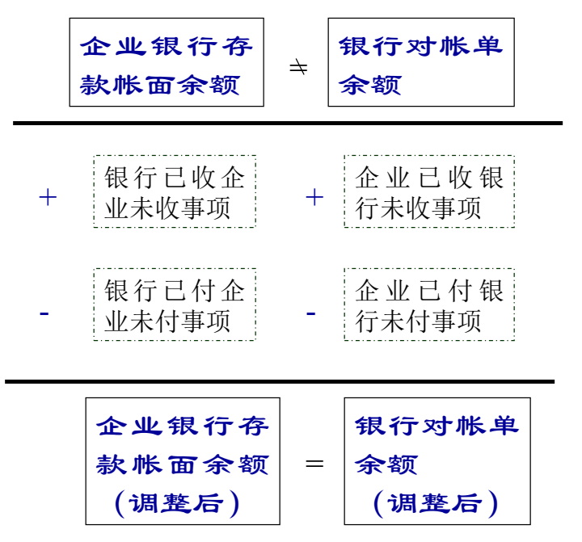

- 浮差（Float）
  - 指公司托收未承付存款，即从银行实际支付的款项数额与银行账面数额之间的差额，也就是公司分类账余额和银行分类账余额之间的差额
  - 当$银行分类账余额>公司分类账余额$，称为支付浮差（payment float）
  - 当$公司分类账余额>银行分类账余额$，称为收取浮差（availability float）
  - 浮差是由支票结算等流程的时滞产生的

##### 应收款项与坏账

- 应收款项
  - 应收账款
  - 应收票据
  - 其他应收款
- 应收账款分析
  - 应收账款总额
    - 比较分析：$\frac{\Delta 应收账款}{\Delta 销售收入}$
    - 结构分析：$\frac{应收账款/总资产}{(应收账款/总资产)_{同业}}$
  - 应收账款构成
    - 主要客户
    - 账龄分析(出现在财报附注中)
      - 账龄上升，说明催收能力较弱
      - 1年以内的应收账款在企业正常信用期限范围内；
      - 1～2年的应收账款虽属逾期，但也属正常；
      - 2～3年的应收账款风险较大；
      - 而3年以上的应收账款通常回收的可能性极小
  - 应收账款变化趋势
  - 坏账准备计提
  - 应收账款管理（合理商业信用政策的制定）
- 应收账款预警信号
  - 主营业务收入增长速度远不及应收账款增长速度；
    - 迅猛增加的应收账款往往预示着业绩风险，意味着企业进行了大量赊销，很多现金可能收不回来
  - 应收账款绝对数额巨大；
  - 应收账款相对数额巨大（与经营性现金流CFO相比）
  - 应收账款集中在少量客户身上；
  - 应收账款畸低
- 案例：分众传媒
  - 2017年以前，毛利率达到70%多
  - 广告业的“先服务，后付款”会计上体现为应收账款
  - 2014~2016，$\frac{应收账款}{营业收入}$为$21\%$~$27\%$
  - 平均账龄较小，多为一年以内
  - 应收账款比例可以看出媒体公司在产业链上的强势程度
    - 与之相比，新浪微博$\frac{应收账款}{营业收入} = 0\%$
- 应收账款过高案例：四川长虹
  - 2000~2003年不计提坏账准备，2004年一次性计提坏账27亿美元，导致了36亿的亏损
  - 董事长与APEX公司合谋，放任APEX公司侵吞公司资产
- 应收账款过少案例：蓝田股份
  - 财务造假，实际上没有那么多业务发生
  - 理由：“采用钱货两清方式结算”
- 其他应收款
  - 包括了关联公司（母子公司）的借款，可能存在关联方资金占用
- 案例：三九医药
  - 2001年，三九医药的母公司三九集团占用了30多亿资金
  - 大股东持续欠款，却一直不计提坏账准备
  - 其他应收款远远多于应收账款，坏账准备却很少

##### 预付账款

- “预付账款”的风险
  - 现象：
    - 预付账款金额较大，占总资产比明显偏高，账龄偏长。
    - 包括预付设备款、预付工程款
  - 问题：
    - 公司存在大股东挪用占用上市公司资金，或是恶意抽逃、转移资金， “掏空” 公司的风险，以及虚增资产的可能性大。
- “三高” 的风险
  - 现象：
    - 应收账款、其他应收款与预付账款占比明显偏高
  - 问题：
    - 公司存在的风险及虚增资产的可能性大
- 预付款过高案例：江苏阳光
  - 2007财年，$应付账款/总资产$增加$19\%$
  - 先转移了资金，而后董事会才审议通过工程
  - 工程项目进展奇慢，而预付款比例却很大
- 利用预付款转移资金：湘鄂情-中科云网
  - 2013年半年报预付款2.27亿，其中前三名相关方与主营业务无关，而且很快陷入诉讼
  - 2014.10湘鄂债被评为垃圾级，董事长跑路

##### 存货

- 存货的定义
  - 公司里的库存，包括原材料、在产品、产成品等。
  - “还有多少隔夜粮”，是维持正常经营重要的问题。
- 把握几点：
  1. 存货的构成
     - 原材料
     - 库存商品
       - 在商品生命周期较短的行业，$\frac{原材料}{库存商品}$可以用于估计企业成长性
     - 委托加工物资
     - 发出商品(已经发货，但是尚未收到货款的商品)
       - 发出商品如果损毁，供应商负全责
       - 发出商品越少，企业在供应链越强势
  2. 存货计价方法选择
     1. 先进先出
     2. 后进先出
     3. 平均成本
     4. 个别计价(大件)
  3. 存货储备量是否合理
     - 存货涨价期间储备多——合理，否则不合理
       - 存货储备有周期性的行业要特别关注这点。
  4. 存货跌价准备的计提与转回
- 发出存货的计价方式
  - 鸿达外贸公司的进出口商品展销厅中，有两辆进口高级助动车，两车除红、白颜色不同外，其他全部相同。红车订于11月份，成本为66000元，共订购20辆；白车订于12月份，但由于美元对人民币汇率的变动，成本仅为54000元，共订购30辆。 50辆助动车同船抵达港口，并运至商品展销厅。由于两车系同厂同车型，两种颜色均很受欢迎，因此，鸿达公司将两车售价均定为95000元。
    - 问题：将成本较低的白车打折出售，对公司有没有好处？
  - 答：取决于公司发出存货的计价方式。
    - 如果采用先进先出法、后进先出法或平均成本法，那么白车的成本与红车没有区别，对公司没有好处；如果采用个别计价法，白车存货的成本低于红车，对公司有好处。
- 存货构成案例：有友食品
  - 专利：泡椒凤爪；
  - 行业特点：竞争激烈，山寨横行，供应链管理很重要
  - 2017年，绝味食品和周黑鸭无发出商品，而有友商品存在120多万的发出商品
    - 有友食品在供应链不够强势
  - $99\%$产品库龄小于1个月
  - 2014~2016年，$\frac{原材料}{库存商品}$持续下降
    - 未来成长性不足
- 存货周期案例：鄂尔多斯
  - 羊绒纺织品存在季节性波动：第二季度大量备货，其余季度存货下降
  - 问题：存货总额不符合常规季节性波动；每年存货增长$20\%$，资金占用较多 $\to$资金被暗中占用？
- 存货跌价准备案例：葫芦岛锌业股份
  - 利用存货跌价“洗澡”：反正要亏了，把跌价准备全部用上达成巨亏，第二年又将跌价准备转回，从而实现“盈利”
  - 2008年一次性计提4.5亿原材料和生产成本的存货跌价准备
  - 库存商品却没有计提跌价准备，反而转回6800万跌价准备
    - 然而此时锌价正处于低谷，报表的理由却是"产品价格上升"
    - 目的：尝试减少Big Bath带来的巨额盈利波动
- 存货过多，意味着存在商品积压，是企业面临的最严重的财务风险之一。
  1. 占用流动资金
     - 由于对流动资金的大量占用，企业面临现金流量不足的压力，不得不增加有息负债的规模，从而使企业负担的财务费用迅速上升；
  2. 资产减值风险
     - 其跌价准备的计提将使企业负担的资产减值损失迅速上升，从而给企业业绩造成巨大的压力。 因此，迅猛增加的存货往往预示着业绩风险
- 比较分析：$\frac{\Delta 存货}{\Delta 营业收入}$
  - 将存货的变化与营业收入的变化加以比较。
  - 一般说来，存货与营业收入规模存在一定的正相关。正常情况下，企业的营业收入规模越大，存货的规模越大；企业的营业收入规模越小，存货规模越小。
  - 因此，如果存货的增长率明显大于营业收入的增长率，则说明存货过多。
- 结构分析：
  - 将企业存货占总资产的比例$\frac{存货}{总资产}$与同行业其他企业的情况加以比较。
  - 一般来说，每一个行业都有其独特的存货结构。如果企业的存货占总资产的比例显著超过同行业的一般水平，则往往说明存货过多。
- 比率分析：
  - 将企业的存货周转率与同行业其他企业的情况加以比较。
    - 如果企业的存货周转率显著低于同行业的一般水平，则往往说明存货过多，周转过慢。
  - 存货周转率：$存货周转率＝\frac{平均营业成本}{存货平均余额}$
    1. 要与企业**毛利率**联系起来(正常状态下，二者应当同向变化)
       - 通常， 存货周转率下降，表明公司存货项目的资金占用增长过快，超过了其产品销售增长速度，其毛利率应趋同下降才合理
       - 同时，存货周转率下降也说明了产品竞争力下降，竞争力不强，毛利率也必然下降。
       - 两者背离则说明有财务造假迹象，抑或是通过打价格战降价来增加销售额，是不可持续。
       - 正常状态下，存货周转率与应收账款周转率也存在同向变化关系

[output not shown]

- 存货与财务造假
  - 利用少结转成本来虚增利润$\to$存货积压时间变久，存货周转率下降，存货周转天数上升
  - 特征：
    1. 毛利率异常，肯定高于可比年度，也肯定高于同行业企业。
    2. 由于未及时结转的成本留存在存货（在产品、产成品）中，公司存货会越来越多，存货周转率也会明显下降。
- 案例：东阿阿胶
  - 2019年出现4亿多亏损，为1989年上市以来首次
  - 经营困难：营收、归母净利润、毛利率大幅下降；存货周转率、应收账款周转率下降
  - 应收账款周转率下降：下游客户议价能力减弱，厂家与经销商之间关系被颠覆
  - 存货周转率下降：渠道商大量囤货，销售渠道减弱，存货积压严重
    - 东阿阿胶曾多次提价，导致经销商大量囤货
    - 媒体打假导致阿胶需求减少
  - 2019年计提了大量库存商品跌价准备和坏账准备，表明销售能力变差

#### 长期股权投资(难点)

- 会计方法取决于投资比例
- 长期股权投资核算方法
  1. 成本法
     - 长期投资按**实际成本**计价和反映。
       - 除非被投资企业支付清算性股利（ Liquidating Dividends)，或者长期股权投资发生永久性贬值，否则，长期股权投资的帐户余额将不受被投资单位净资产变动的影响。
       - 历史成本包括购买价格及相关税费（如支付给券商的佣金、印花税以及其他相关附属费用），但不包括为取得长期股权投资所发生的评估、审计、咨询等费用，也不包括CDD
       - 会计处理：

         \begin{align*} Dr:& 应收股利（或银行存款）\space\space xxx\\ &Cr:投资收益 \space\space xxx \end{align*}
     - 适用范围：
       1. 对被投资单位无控制、 无共同控制且无重大影响
          - （一般为拥有被投资单位20%以下表决权资本）
       2. 不准备长期持有被投资单位的股份。
       3. 被投资单位在严栺的限制条件下经营， 其向投资企业转移资金的能力不到限制。
          - 拥有被投资单位20%以下股权;
          - 拥有20%以上但未有重大影响
  2. 权益法
     - 投资投入时以投资成本计价，以后根据投资企业享有被投资单位所有者权益份额的发放对投资的帐面价值进行调整的方法。
     - 适用范围：
       - 对被投资单位具有控制、 共同控制或重大影响。
         - 即拥有被投资企业20%及以上表决权股权。
     - 会计处理：
       - 长期股权投资应按贩买股权时的历史成本计价。

         \begin{aligned} 借：&长期股权投资 ×××\\ &贷：银行存款 ××× \end{aligned}
         - 若$初始投资成本>应享有被投资单位可辨认净资产公允价值份额$ (溢价收购)，则将溢价部分记为*商誉*
         - 若 $初始投资成本<应享有被投资单位可辨认净资产公允价值份额$ (折价收购)，差额部分计入当期损益（投资收益），同时调整长期股权投资成本
       - 会计期间终了，根据股权取得日后被投资单位的盈亏情况，按股权比例确认投资损益，并相应调整长期股权投资帐户。

         \begin{aligned} 借：&长期股权投资—A公司（损益调整） ×××\\ &贷：投资收益—股权投资收益 ××× \end{aligned}
       - 被投资单位宣告或发放现金股利时，应冲减长期股权投资帐户。

[output not shown]

- 个别报表 & 合并报表
  - 如果A公司控股了B公司，那么对B公司的投资在个别报表和合并报表中有不同的处理方法
  - A公司个别报表：对B公司的投资属于*长期股权投资*，按照*成本法*计量
  - 合并报表：在合并报表中，使用*权益法*调整对B公司的股权投资
- 投资收益如何确认？(权益法)
  - 投资企业收取现金股利——长期股权投资收回
  - 被投资单位发生了除净损益以外的其他所有者权益变动；
    - 持股比例不变——调整资本公积及长期股权投资
    - 持股比例变动——未予说明
  - 被投资单位发生净损益，投资企业在确认应享有被投资单位净损益的份额时，应当以*取得投资时*被投资单位各项**可辨认净资产的公允价值**为基础，对被投资单位的净利润进行调整后确认。
    - 例如，$认定被投资企业净利润 = 原始净利润 + 可辨认资产账面折旧 - 投资时的可辨认资产公允价值折旧 $
- 案例：天津磁卡(生产验钞机)
  - 2001年向子公司销售2.15亿产品
  - 而后2次转股，卖出子公司股票，从此子公司不再是关联公司
  - 第一次转股，是为了将子公司转出合并报表，避免销售收入与利润被抵消
  - 第二次转股，是为了将子公司从关联公司名单中剔除
    - 这是为了规避财政部对关联交易的监管新规

##### 股权投资:掏空 & 利益输送

- 区分：重大影响 & 控制
  - 重大影响 ：参与、但不决定公司治理
  - 控制：决定公司决策
- 控制的界定
  - 控制是指有权决定一个企业的财务和经营政策，并能据以从该企业的经营活动中获取利益。
  - 控制和是否持有股权没有必然关系
    - （实质重于形式：20%和50%的界限并非是死线）
    - 例如：如果A公司没有控股B公司，但是B公司董事会成员大都是A公司的人，那么A公司同样控制了B公司
  - 在确定是否能对被投资单位实施控制（或施加重大影响时），应考虑投资企业和其他方持有的被投资单位当期可转换公司债券、当期可执行认股权证等潜在因素。

##### 股权结构：平分股权结构

- 案例：镛记酒家
  - 创始人生前以45%，45%，10%将股权分给二男一女
  - 大儿子与二儿子在连锁店问题上出现分歧，二儿子联合小女儿，形成优势
  - 二人的股权收购协议无法达成，最后进入诉讼

##### 股权设计

- 如何加强大股东控制权？
  - 不平等投票
    - 双重表决：创始人持有1股n票的特殊股，同时让渡分红权利
    - 合伙人投票权：在公司章程中设置提名董事会的特殊条款(确保董事会控制权)
      - 阿里巴巴的合伙人制度：相当于董事会中的董事会，确保符合管理层利益的人进入董事会
    - 成立有限合伙企业作为控股公司：$创始人 \to 有限合伙企业 \to 上市公司$
      - $马云 \to^{100\%} 云铂 \& 高管 \to 君洁、君济等有限合伙 \to 蚂蚁金服$
  - 毒丸计划
    - 第一代毒丸：发行优先股
      - 特殊情况下，特殊股股东可以恢复表决权，从而增加收购成本，遏止恶意收购
    - 第二代毒丸：外翻式毒丸
      - 若收购人收购了大量股份，其他股东可以半价购买公司股票
  - 金字塔控股
    - 企业的控股结构呈层级式的金字塔状
    - 大股东作为控股股东处于金字塔的顶端，他不直接控制企业，而是通过一层、两层、三层甚至更多的中间公司去控制最终企业
    - 控制权 & 现金流量权
      - 控制权（control rights）
        - 控制权（投票权）指的是最终控制人参与企业经营、 财务等决策的权力， 通常以重大决策中的投票权来实现
        - 采用控制链上离被控制企业**最近的持股比例**计量 $\argmin_{d(i\to j)}\omega$
      - 现金流量权（cash flow rights）
        - 现金流量权（所有权）指的是最终控制人参与企业现金流分配的权力，是所有权的直接体现
        - 采用控制链上**各个控制环节的持股比例的乘积**计量 $\prod_{i\to k}^{j}\omega_k$
  - 交叉控股
    - 相互持有对方股份，互为股东
    - 为了保护自身的股权，可以让集团内公司互相交叉持股，从而避免被轻易收购
- 有限合伙企业控股案例：宝亿嵘影业(王宝强个人工作室)
  - 成立初期，前妻马蓉持股比例90%，王宝强并不持股
  - 2016.3 变为王宝强、任晓妍、宋喆自然人控股
  - 2016.4 王宝强(5%) + 有限合伙公司(王宝强 37.5%，马蓉 31.25%，任晓妍 31.25%)，其中马蓉仅有收益权
    - 可能这期间马蓉出轨，宋喆被踢出
- 金字塔控股案例：辛格浩家族 & 乐天集团
  - 除了乐天集团以外，金字塔控股形式在东南亚家族企业中更为常见
  - 利用金字塔控股的控制人往往有很强的出卖中小股东利益的动机
- 交叉持股案例：怡和集团
  - $子公司(未上市){}^{79\%}\leftrightarrow^{51\%}母公司(上市) $

##### 会计核算方法改变 & 利润操纵

\begin{cases} 成本法，if\space 持股比例<20\%\\ \space \text{ 无控制、共同控制或重大影响，且在活跃市场中没有报价、公允价值不能可靠计量的长期股权投资} \\ \space \text{ 不包括可供出售金融资产} \\ 权益法，if\space 20\%\leq 持股比例\leq 50\% \\ \space \text{ 共同控制 or 重大影响} \\ 成本法 \& 合并报表，if\space 持股比例>50\% \\ \space \text{ 重大影响} \end{cases}

- 案例：力帆股份
  - 2013年，力帆股份大量增持重庆银行，将成本法变为权益法，从而使净利润大大增加
  - 然而，力帆的持股比例并没有超过$20\%$，对此，力帆找了很多理由
  - 2013至2016年，对重庆银行投资占据了力帆当期营业利润的59%~2864%
  - 这种操作是合法的
- 案例：上汽集团
  - 2017年合并报表营收800多亿
  - 2016年长期股权投资账面价值626.77亿，投资收益305.72亿，带来净利润439亿
  - 2005年：对通用汽车持股比例由19%上升为20% $\to$ 成本法变为权益法
  - 2010年重组：购买通用中国1%股份，持股比例最终达到51% $\to$ 权益法变为成本法，合并报表 $\to$ 营收大大增加
  - 2012年：通用中国又回购股份，上汽不再控股通用中国 $\to$ 成本法变为权益法
  - 2009年：华域汽车借壳上市，上汽收购20%股份(权益法)
  - 2011年：收购华域汽车，合并报表后得到其营收
- 案例：康宁医院
  - 国内最大的私营精神病院集团
  - 子公司包括各地康宁医院以及一个房地产公司温州国大
  - 并不实际控股各地康宁医院，只收取“服务费”
    - 这种方法类似酒店集团，将酒店管理的轻资产部分剥离出去
  - 平阳长庚(康宁持股0%)：由康宁创始人成立转让给股权代持方(康宁的股东鼎晖)，2011~2017年一直在进行关联交易
    - 关联交易非关联化
  - 北京怡宁：2016年康宁出资进入金浦基金，金浦基金又溢价增资北京怡宁，2017年上半年账面出现了524.34万投资收益
    - 利用“投资收益”提升净利润
  - 温州国大：2016年收购了温州国大75%股权，纳入合并报表范围，纳入729万的投资性房地产。如果房价下跌，又可以将股权卖出至20%~50%阶段，避免资产减值
    - 相当于“备胎公司”
- 案例：厦门航空
  - 股东：60%南航 + 40%厦门建发
  - 2002年厦航报表：净利润7796万，净资产12.02亿
  - 2003年南航招股说明书：净利润4.36亿，净资产28.66亿
  - 原因：厦航采用了更加严格的折旧计提政策，与母公司南航不同

#### 金融工具：确认 & 计量(重点)

- 金融资产(旧准则)
  - 交易性金融资产
    - 以公允价值计量且其变动计入当期损益的金融资产
  - 持有到期投资
  - 贷款和应收款项
  - 可供出售金融资产
- 金融资产(新准则)
  - 以*公允价值*计量且其变动计入*当期损益*的金融资产（交易性金融资产）
  - 以*公允价值*计量且其变动计入*其他综合收益*的金融资产（可供出售金融资产）
  - 以*摊余成本*计量的金融资产（持有到期投资 & 贷款和应收款项）

    \begin{align*} 期末摊余成本&=未来现金流量按实际利率折现 \\ 减值损失&=期初摊余成本-期末摊余成本 \\ 摊余成本&=初始确定金额-已偿还本金±累计摊销额-减值损失 \end{align*}
- 重新分类
  - 持有到期投资和可供出售金融资产可以互相重新分类，但是若重分类总额较大，则2年内不能再次重新分类
    - 相当于提前出售持有到期投资的惩罚性条款
- 交易性金融资产 & 可供出售金融资产？
  - 持有期限：
    - 交易性金融资产： 持有短期，随时准备卖出
    - 可供出售金融资产： 持有不定期限，可以用于出售
  - 初始计量：
    - 交易性金融资产：公允价值
    - 可供出售金融资产：公允价值 + 交易费用
  - 后续计量：
    - 交易性金融资产：公允价值
    - 可供出售金融资产：公允价值
  - 价值变动处理：
    - 交易性金融资产：不计提减值准备；公允价值变动计入**当期损益**
    - 可供出售金融资产：计提减值准备；公允价值变动计入**其他综合收益**，直到出售时才转入当期损益
  - 与交易性金融资产价格变动就要计入损益不同，可供出售金融资产可操纵性更强，可以按需求卖出资产来增加利润
    - 在新准则下，卖出可供出售金融资产不再计入当期损益，而是留存收益，不再能直接增加利润
- 会计处理：交易性金融资产
  - 原则
    - 以公允价值计量
    - 交易费用在发生时直接计入当期损益
    - 对交易性金融资产不再计提减值准备
- 会计处理：可供出售金融资产
  - 原则
    - 初始投资成本包括支付价款和相关交易费用
    - 持有期间应以公允价值计量
    - 因公允价值变动形成的利得或损失应直接计入所有者权益，并在该项投资对外出售时转出，计入当期损益

股权投资 = \begin{cases} 长期股权投资 \\ \space\space\space\space\text{ If 控制、共同控制或重大影响} \\ \space\space\space\space\text{ Or 无控制、共同控制或重大影响 \& 无控制、共同控制或重大影响} \\ 可供出售金融资产 \\ \space\space\space\space\text{ If 无控制、共同控制或重大影响 \& 公允价值能可靠计量} \\ 交易性金融资产 \\ \space\space\space\space\text{ If 短期股权投资} \\ \end{cases}

债权投资 = \begin{cases} 持有至到期投资 \\ \space\space\space\space\text{If 长期 \& 目的持有至到期} \\ \space\space\space\space\text{Or 短期 \& 若到期日一年以内，且准备持有至到期} \\ 可供出售金融资产 \\ \space\space\space\space\text{If 长期 \& 目的不明确或不准备持有至到期} \\ 一般应为“交易性金融资产” \\ \space\space\space\space\text{Or 短期 \& 不确定是否持有到期} \\ \end{cases}

- 可供出售金融资产调整利润案例：雅戈尔
  - 2007~2015年，$\frac{股权投资}{当期利润总额}$高达39.94%
  - 直接卖出股票：大量股票投资放在可供出售金融资产，当需要增加账面利润时就卖出股票
  - 变更会计政策：2018年4月增持中信股份的股票($4.99\%\to5.00\%$)，将中信股份的股票由可供出售金融资产转入**长期股权投资**，以*权益法*确认损益
    - 其中$5\%$的股份是一个重要的阈值，收购上市公司股票达到这个阈值就一定要向投资者公告(“举牌”)
    - 一般而言，想要对上市公司施加“重大影响”，派遣非执行董事是最常见的方法
  - 但是利用可供出售金融资产并非没有坏处，可供出售金融资产的收益属于所有者权益的一部分，从而可能使净资产膨胀，拉低$ROE = \frac{净利润}{净资产}$与$P-E = \frac{股价}{净资产}$
- 案例：招商轮船
  - 2007年前，存在中集集团和中海发展两个战略投资者
    - 2007年是罕见的牛市
  - 2007年半年报中，中海发展报告$ROE = 16.24\%$,中集集团报告$ROE = 9.77\%$
  - 原因：对招商轮船股份会计处理不同
    - 中海发展：交易性金融资产
    - 中集集团：可供出售金融资产
- 案例：南京高科
  - 是南京银行的第三大股东
  - 2006~2007:$EPS\uparrow$,$ROE\downarrow$
  - 原因：持有股票价值大大增加，净资产膨胀
- 案例：美的收购小天鹅
  - 2007年美的以控股为目的尝试收购小天鹅
  - 但是2006年收购的股份却划入了*交易性金融资产*
    - 由于2007年是牛市，属于交易性金融资产可以给企业带来账面浮盈，从而拉高股价

#### 投资性房地产

- 定义
  - 指为赚取租金或资本增值，或两者兼有而持有的房地产。投资性房地产应当能够单独计量和出售
- 范围
  - 已出租的土地使用权。
  - 长期持有并准备增值后转让的土地使用权。
  - 企业拥有并已出租的建筑物。
- 自用房地产与生产性房地产不属于投资性房地产
- 特殊情况
  1. 一项房地产部分用于赚取租金或资本增值，部分用于生产商品、提供劳务或经营管理，用于赚取租金或资本增值的部分，如果能够分别计量和出售的，可以确认为投资性房地产
  2. 企业将建筑物出租并按出租协议向承租人提供保安和维修等其他服务，所提供的其他服务在整个协议中不重大的，可以将该建筑物确认为投资性房地产；所提供的其他服务在整个协议中如为重大的，该建筑物应视为企业的经营场所，应当确认为自用房地产
  3. 关联企业之间租赁房地产，出租方应将出租的房地产确定为投资性房地产。但在编制合并报表时，应将其作为企业集团的自用房地产。如母公司以经营租赁给子公司的房地产，应当作为母公司的投资性房地产，但在编制合并报表时，作为企业集团的自用房地产
  4. 企业拥有并自行经营的旅馆饭店，不履属于投资性房地产。如果将其拥有的旅馆饭店部分或全部出租，且出租的部分能够单独计量和出售的，出租的部分可确认为投资性房地产
- 初始计量：企业取得的投资性房地产，应当按照取得时的成本进行初始计量。
  - 外购投资性房地产：包括*购买价款*和可直接归属于该资产的*相关税费*。
  - 自行建造投资性房地产：由建造该项资产达到预定*可使用状态前*所发生的必要支出构成。
  - 以其他方式取得的投资性房地产的成本，适用相关会计准则的规定确认。
- 后续计量：企业应当在资产负债表日采用**成本模式**对投资性房地产进行后续计量，
  - 有确凿证据表明投资性房地产的公允价值能够持续可靠取得的情况(有活跃市场报价)下除外
  - 投资性房地产的成本模式可以转为**公允价值模式**，但不能改回来
- 转换：企业有确凿证据表明房地产用途发生改变，满足下列条件之一的，应当将投资性房地产转换为其他资产或者将其他资产转换为投资性房地产：
  - 条件：
    - 投资性房地产开始自用。
    - 作为存货的房地产，改为出租。
    - 自用土地使用权停止自用，用于赚取租金或资本增值。
    - 自用建筑物停止自用，改为出租。
  - 转换方法：
    - 成本模式：用转换前的账面价值转入固定资产
    - 公允价值模式：以其转换当日的公允价值作为自用房地产的账面价值；账面价值与公允价值的差额计入当期损益
- 成本模式 & 公允价值模式
  - 公允价值模式的特点
    - 采用公允价值模式计量的， 不对投资性房地产计提*折旧*或进行*摊销*
    - 公允价值与原账面价值之间的差额计入当期损益
  - 取得：

    \begin{align*} 借：&银行存款 \\ &贷：其他业务收入 \\ \\ 借：& 其他业务成本 \\ &贷：投资性房地产——成本 \\ & 投资性房地产——公允价值变动 \end{align*}
- 利用变更计量模式进行盈利管理
  - 好处
    - 转换后的投资性房地产不计提折旧或摊销，减少了企业的费用支出
    - 房地产价格上涨的条件下投资性房地产的公允价值增加能够在当期确认为公允价值变动损益
    - 会计政策的变更不增加企业的税收负担
- 利用公允价值模式获得利润 案例：昆明百货
  - 百货公司虽然辉煌不再，但是商场的地段非常好
  - 2008年，投资性房地产占23.6%，由成本模式转为公允价值模式
  - 2009~2010年，投资性房地产公允价值变动占利润75%左右
- 公允价值模式→历史成本模式 案例：深发展银行
  - 2011年，直接宣布调整会计政策，将公允价值模式变为历史成本模式
  - 2011年，深发展银行被平安集团收购，采用母公司会计政策
- 案例：泸州风投(地方政府融资平台)
  - 2016年投资性房地产占比$20\%$，采用公允价值模式计量
  - 主营业务毛利为负，依靠公允价值变动损益达成盈利
  - 存在大量不良资产，2017年财政部发文要求地方政府融资平台自负盈亏
  - 不良资产里面，包含大量在建工程
    - 在建工程包含煤制气工程投资，而当时天然气价格突然暴跌，煤制气难以继续推进
    - 煤制气工程完工之后，天然气价格仍没有上涨
    - 为了避免每年7~8亿的亏损，煤制气工程仍然保持在建工程，没有转入固定资产
  - 应对方法：
    - 剥离石化公司，保证泸州风投能活下去
    - 用*工作量法*计提煤制气工程折旧

#### 固定资产（期中不考！）

- 调整折旧政策 案例：宝钢股份
  - 2003年，钢材价格大涨，钢铁企业利润大大增加
  - 2003年，将年折旧率增加到7%，从而缩减利润90个亿
- 折旧四种方法
  - 年限平均
  - 工作量法
  - 双倍余额递减法
  - 年数总和法
- 关键参数
  - 折旧年限
  - 预计净残值
- 利用资产减值损失进行Big Bath 案例：中海油服
  - 2016年巨亏114.59亿，原因是计提了82.73亿的资产减值损失
  - 2017~2018年，又转回资产减值，从而扭亏为盈
  - 由于计提了大量资产减值损失，还为以后节省了大量折旧
  - 以后出售资产，可以带来更多的账面价值
- 固定资产租赁
  - 经营租赁
  - 融资租赁
    - 会计处理：融资租赁属于*负债*
      - 融资租入固定资产，应当在租赁开始日，按租赁开始日租赁资产的原账面价值不最低租赁付款额的现值两者中较低者作为入账价值。
      - 借记“在建工程”戒“固定资产”科目，按最低租赁付款额，贷记“长期应付款-应付融资租赁款” 科目，按其巩额，借记“未确认融资费用”科目。
      - 按期支付融资租赁费时，借记“长期应付款-应付融资租赁款”科目，贷记“银行存款”科目。
      - 租赁期满，如合同规定将设备所有权转归承租企业，应当迚行转账，将固定资产仅“融资租入固定资产”明细科目转入有关明细科目。
  - 为什么大部分企业不愿意确认融资租赁，而只将其在表外进行披露呢？
    - $\frac{L}{A} \leq \frac{L+融资租赁}{A+融资租赁}$：容易拉高负债率

##### 在建工程

- 在建工程
  - 准固定资产
    - 期末各项未完工程的实际支出
    - 不提折旧
  - 容易造假：项目虽已完工，但迟迟不转入固定资产，少提折旧，提高利润。
  - 若附注中有一项工程几年都没有完工，应警惕
- 案例：荣华实业
  - 2008至2013年，价值8个亿的在建工程基本停滞，也没有拿出来做抵押
  - 很可能是虚增资产，涉嫌资金挪用

#### 无形资产

- 无形资产的定义
  - 无形资产指没有实物形态的可辨认非货币性资产。
  - 不再区分可辨认无形资产和不可辨认无形资产
  - 把*商誉*排除在外
- 研发支出的规定
  - 企业**研究**阶段的支出**全部费用化**，计入当期损益（管理费用）；
  - **开发**阶段的支出符合条件的才能**资本化**，不符合资本化条件的计入当期损益（管理费用）。
    - 只有同时满足无形资产准则规定的各项条件的，才能确认为无形资产，否则计入当期损益。
    - 如果确实无法区分研究阶段的支出和开发阶段的支出，应将其所发生的研发支出全部费用化，计入当期损益
    - 然而，如何确定研究-开发阶段，主动权其实在公司手中，因此可操纵性较强
- 研发支出资本化案例：大唐电信
- 案例：海正药业
  - 主要生产抗生素、抗肿瘤药物
  - 2015年收入同比下降13.17%；归母净利润同比下降95%
  - 2015年之前没有出现“开发支出”(非流动资产)，2015年出现3.34亿开发支出
  - 内部开发支出增加3.09亿，只有5000万转入当期损益
- 借壳上市案例：360公司
  - 2011年在纽交所上市，2015~2016年完成私有化，从纽交所摘牌；2017年借壳江南嘉捷上市，回归A股
  - 为何退出美股？
    - 2015~2020年，大量中概股被对冲基金和做空公司(例如Muddy Water、The Street)做空还有集体诉讼
    - 美股和港股容易导致股价被低估
      - 美股：博纳影业48.55亿
      - A股：光线传媒337.07亿；重新上市的博纳影业100多亿
    - 在美股进行收购会以国家安全理由被调查
  - 借壳流程
    1. 壳公司把资产转给子公司
    2. 把子公司控制权卖给原控制人
    3. 360将自身资产注入壳公司，收购取得控制权
- 研发投入案例：360
  - 2014~2016年，20多亿的研发投入全部计入管理费用，不进行资本化
  - 直到今天，研发投入资本化率始终为0
- 案例：通化金马
  - 1999年~2000年，民营企业三利化工取代国资委成为第一大股东
  - 2667万买了北京一个公司(营收只有800多万)，另外用3.45亿购买了技术"奇胜胶囊"
  - 2000年，"奇胜胶囊"带来了收益14.85亿
  - 2001年，因为涉嫌国有资产流失，三利化工收购中止
  - 2001年，计提"奇胜胶囊"全部减值准备，理由是“销路不畅”
  - 2002年，又转回减值损失，做了Big Bath
  - 显然，购买"奇胜胶囊"是为了运作无形资产
- 案例：科龙电器
  - 2004年，郎咸平发表《在国退民进盛宴中狂欢的格林柯尔》，针对科龙电器控制人顾雏军
  - 2000年，科龙电器从盈利6.4亿变为亏损6.7亿
  - 2001年，科龙电器EPS降为-1.63元，甚至因为大股东欠款和占用资金被停牌
  - 2002年~2003年，格林柯尔(离岸注册的外资独资)利用多种手法，只用9亿就撬动了100亿的国有资产
    - 安营扎寨：注册大量独资公司，看起来毫无关联
    - 趁虚而入：大量收购经营困难但是品牌较好的国有上市公司
    - 反客为主：股权转让完成之前，就成为公司董事长，让副手成为总裁
    - 投桃报李：和大股东私下交易，低价收购国有股份，以无形资产抵消股东欠款作为交换
    - 洗个大澡：2001年，一次性计提大量减值准备，达成巨亏
    - 相貌迎人：2002年，转回大量费用，达成微利，股价回升
    - 借鸡生蛋：利用科龙的账面现金继续收购其他上市公司

#### 商誉

- 商誉（ goodwill） 的含义？
  - 商誉是指能在未来期间为企业经营带来超额利润的潜在经济价值，戒一家企业预期的获利能力超过可辨认资产正常获利能力的资本化价值。
  - 非同一控制下企业合幵时，买方对合幵成本，大于合幵中取得的被购买方可辨认净资产公允价值份额的差额。
  - 简单说，就是收贩时支付总对价，高二幵贩标的净资产公允价值的部分，也可以叫做收贩溢价
- 商誉是如何产生的？
  - 商誉产生的根源是收贩兼幵活放产生的幵贩巩价
  - 如果没有合并报表，商誉就会转成其他形式的投资
- 收购对价：$$收购对价_t = 公司价值_t *\sum_{i=1}^t 收购比例_i$$
- 商誉：$$ 商誉= 收购对价- 净资产的公允价值×持股比例 $$
  - 若净资产为负，则记为0
- 初始计量：并购成本 & 被并购公司的公允价值(存在操纵空间)
- 后续计量：进行减值测算
  - 测算未来现金流
  - 测试折现率
- 操纵方法
  - 夸大并购价值，虚增规模
  - 无法完成业绩对赌时，索性计提全额损失“Big Bath”

```python
(7.56*10**8-10**7*0.7)
```

```
749000000.0
```

```python
10.5*10**8-(1.36-1.91)*10**4*0.7
```

```
1050003850.0
```

- 商誉减值案例：天神娱乐
  - 2018年曾预测明年大量盈利
  - 2018年，由于传言商誉将转为摊销法，一次性计提全额减值，预计亏损49亿
- 案例：纳斯达
  - 2016年，收购打印机巨头Lexmark，二者营收差距20多倍
  - 2016年，纳斯达合并报表出现188亿的商誉
  - 减少49亿商誉，转入股权投资，避免了大量商誉风险
    - 没有合并报表，也就不再体现为商誉
    - 但是，长期股权投资也会减值
- 减值测试案例：益佰制药
  - 2013年并购女子大药厂，女子大药厂没有完成业绩要求
  - 为什么不计提减值？
    - 在减值测试中，调高了未来现金流，调低了折现率